# Iris Data Set Shiny Application

Ella S.

February 10, 2016

## Purpose

The purpose of this application is to demonstrate different features of the shiny framework by Rstudio.

This web application is based on the [famous Iris data set](https://stat.ethz.ch/R-manual/R-devel/library/datasets/html/iris.html)

Inspired from the  
[shiny gallery example](http://shiny.rstudio.com/gallery/kmeans-example.html)

```r
head(iris)
```

```
##   Sepal.Length Sepal.Width Petal.Length Petal.Width Species
## 1          5.1         3.5          1.4         0.2  setosa
## 2          4.9         3.0          1.4         0.2  setosa
## 3          4.7         3.2          1.3         0.2  setosa
## 4          4.6         3.1          1.5         0.2  setosa
## 5          5.0         3.6          1.4         0.2  setosa
## 6          5.4         3.9          1.7         0.4  setosa
```

```r
levels(iris$Species)
```

```
## [1] "setosa"     "versicolor" "virginica"
```

## What it does

This application takes the Iris data set and runs a simple regression model for the different parameters that are choosen from the web interface.

The are 3 Tabs : *Plot/Summary/Photo*

- **Plot** - plots the x, y relation according to different Iris species and also plots the relation for all species.

  x,y axes can be choosen from dropdown lists, which are the Iris flower features

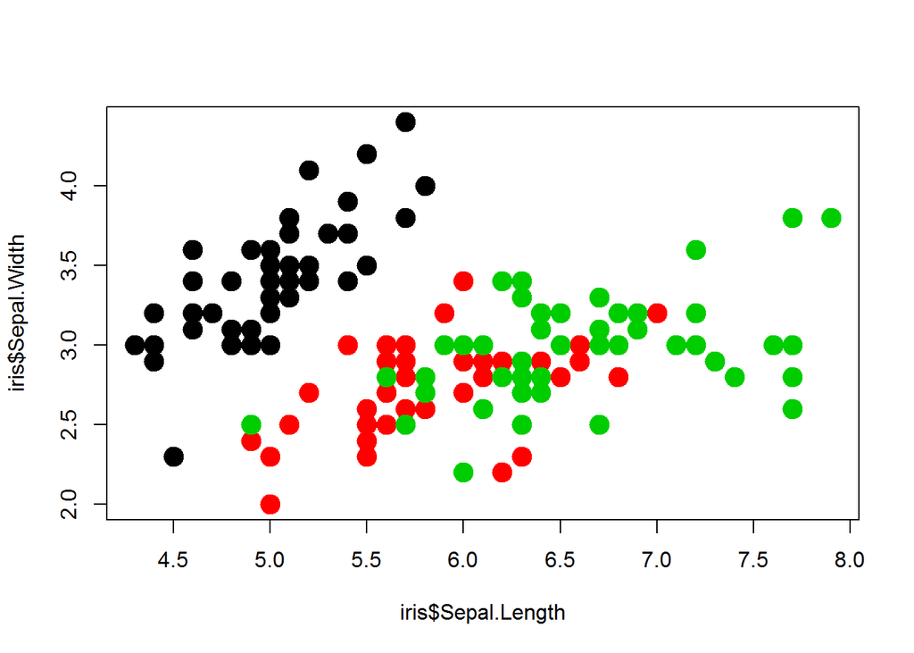

```r
plot(x = iris$Sepal.Length, y = iris$Sepal.Width, pch=20,cex=3,col=iris$Species)
```

- **Summary** - summary for the regression model

```r
   summary(lm(iris$Sepal.Width ~ iris$Sepal.Length))
```

```
##
## Call:
## lm(formula = iris$Sepal.Width ~ iris$Sepal.Length)
##
## Residuals:
##     Min      1Q  Median      3Q     Max
## -1.1095 -0.2454 -0.0167  0.2763  1.3338
##
## Coefficients:
##                   Estimate Std. Error t value Pr(>|t|)
## (Intercept)        3.41895    0.25356   13.48   <2e-16 ***
## iris$Sepal.Length -0.06188    0.04297   -1.44    0.152
## ---
## Signif. codes:  0 '***' 0.001 '**' 0.01 '*' 0.05 '.' 0.1 ' ' 1
##
## Residual standard error: 0.4343 on 148 degrees of freedom
## Multiple R-squared:  0.01382,    Adjusted R-squared:  0.007159
## F-statistic: 2.074 on 1 and 148 DF,  p-value: 0.1519
```

- **Photo** - this tab includes the picture for each Iris species from Wikipedia

## Usage

1. Choose the Iris species from the radio box
2. Choose the x, y axes from the dropdown lists
3. Navigate to Summary tab to see the regression model results
4. Navigate to Photo tab to view Iris picture
5. Choose different options for each tab